# Question 1

# Question 2

**A hospital wants to determine whether there is any difference in the average Turn Around Time (TAT) of reports of the laboratories on their preferred list. They collected a random sample and recorded TAT for reports of 4 laboratories. TAT is defined as sample collected to report dispatch.**

Analyze the data and determine whether there is any difference in average TAT among the different laboratories at 5% significance level.

```python
labtat = pd.read_csv("D:/excelr/assignments/LabTAT.csv")
labtat
```

|  | Laboratory 1 | Laboratory 2 | Laboratory 3 | Laboratory 4 |
| --- | --- | --- | --- | --- |
| 0 | 185.35 | 165.53 | 176.70 | 166.13 |
| 1 | 170.49 | 185.91 | 198.45 | 160.79 |
| 2 | 192.77 | 194.92 | 201.23 | 185.18 |
| 3 | 177.33 | 183.00 | 199.61 | 176.42 |
| 4 | 193.41 | 169.57 | 204.63 | 152.60 |
| ... | ... | ... | ... | ... |
| 115 | 178.49 | 170.66 | 193.80 | 172.68 |
| 116 | 176.08 | 183.98 | 215.25 | 177.64 |
| 117 | 202.48 | 174.54 | 203.99 | 170.27 |
| 118 | 182.40 | 197.18 | 194.52 | 150.87 |
| 119 | 182.09 | 215.17 | 221.49 | 162.21 |

120 rows × 4 columns

```python
labtat.describe()
```

|  | Laboratory 1 | Laboratory 2 | Laboratory 3 | Laboratory 4 |
| --- | --- | --- | --- | --- |
| count | 120.000000 | 120.000000 | 120.000000 | 120.00000 |
| mean | 178.361583 | 178.902917 | 199.913250 | 163.68275 |
| std | 13.173594 | 14.957114 | 16.539033 | 15.08508 |
| min | 138.300000 | 140.550000 | 159.690000 | 124.06000 |
| 25% | 170.335000 | 168.025000 | 188.232500 | 154.05000 |
| 50% | 178.530000 | 178.870000 | 199.805000 | 164.42500 |
| 75% | 186.535000 | 189.112500 | 211.332500 | 172.88250 |
| max | 216.390000 | 217.860000 | 238.700000 | 205.18000 |

```python
labtat.isnull().sum()
```

```
Laboratory 1    0
Laboratory 2    0
Laboratory 3    0
Laboratory 4    0
dtype: int64
```

```python
labtat[labtat.duplicated()].shape
```

```
(0, 4)
```

```python
labtat[labtat.duplicated()]
```

|  | Laboratory 1 | Laboratory 2 | Laboratory 3 | Laboratory 4 |
| --- | --- | --- | --- | --- |

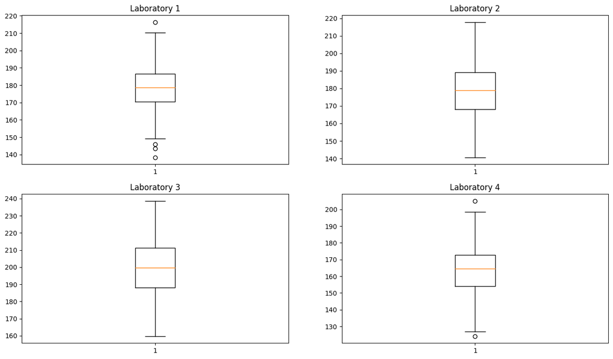

```python
plt.subplots(figsize = (16,9))
plt.subplot(221)
plt.boxplot(labtat['Laboratory 1'])
plt.title('Laboratory 1')
plt.subplot(222)
plt.boxplot(labtat['Laboratory 2'])
plt.title('Laboratory 2')
plt.subplot(223)
plt.boxplot(labtat['Laboratory 3'])
plt.title('Laboratory 3')
plt.subplot(224)
plt.boxplot(labtat['Laboratory 4'])
plt.title('Laboratory 4')
plt.show()
```

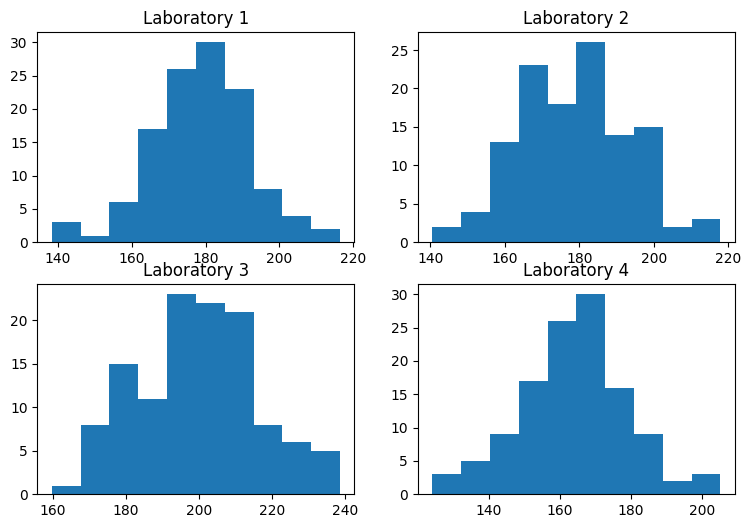

```python
plt.subplots(figsize = (9,6))
plt.subplot(221)
plt.hist(labtat['Laboratory 1'])
plt.title('Laboratory 1')
plt.subplot(222)
plt.hist(labtat['Laboratory 2'])
plt.title('Laboratory 2')
plt.subplot(223)
plt.hist(labtat['Laboratory 3'])
plt.title('Laboratory 3')
plt.subplot(224)
plt.hist(labtat['Laboratory 4'])
plt.title('Laboratory 4')
plt.show()
```

[output not shown]

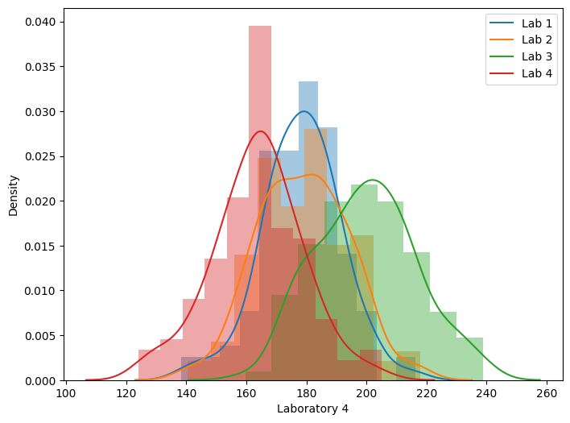

```python
plt.figure(figsize = (8,6))
labels = ['Lab 1', 'Lab 2','Lab 3', 'Lab 4']
sns.distplot(labtat['Laboratory 1'], kde = True)
sns.distplot(labtat['Laboratory 2'],hist = True)
sns.distplot(labtat['Laboratory 3'],hist = True)
sns.distplot(labtat['Laboratory 4'],hist = True)
plt.legend(labels)
```

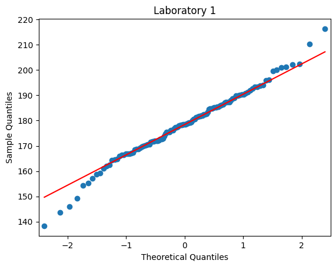

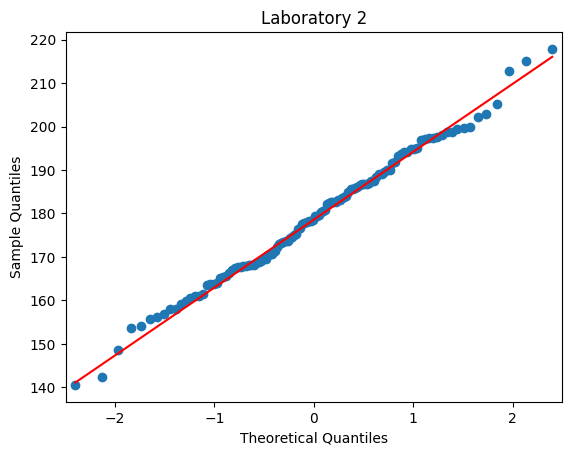

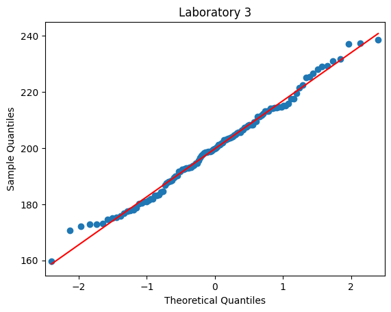

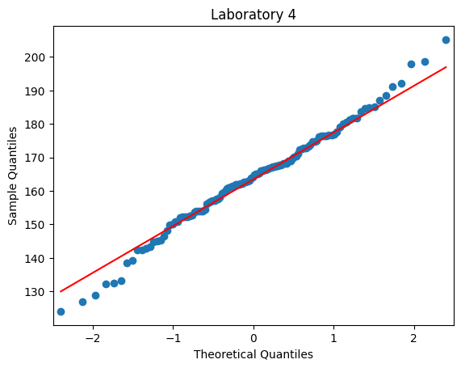

```python
# Plotting Q-Q plot to check whether the distribution follows normal distribution or not
sm.qqplot(labtat['Laboratory 1'], line = 'q')
plt.title('Laboratory 1')
sm.qqplot(labtat['Laboratory 2'], line = 'q')
plt.title('Laboratory 2')
sm.qqplot(labtat['Laboratory 3'], line = 'q')
plt.title('Laboratory 3')
sm.qqplot(labtat['Laboratory 4'], line = 'q')
plt.title('Laboratory 4')
plt.show()
```

```python
# Compare Evidences with Hypothesis using t-statictic
test_statistic , p_value = stats.f_oneway(labtat.iloc[:,0],labtat.iloc[:,1],labtat.iloc[:,2],labtat.iloc[:,3])
print('p_value =',p_value)
```

```
p_value = 2.1156708949992414e-57
```

```python
alpha = 0.05
print('Significnace=%.3f, p=%.3f' % (alpha, p_value))
if p_value <= alpha:
    print('We reject Null Hypothesis there is a significance difference between TAT of reports of the laboratories')
else:
    print('We fail to reject Null hypothesis')
```

```
Significnace=0.050, p=0.000
We reject Null Hypothesis there is a significance difference between TAT of reports of the laboratories
```

# Question 3

[figure not shown]

```python
buyer = pd.read_csv("D:/excelr/assignments/BuyerRatio.csv")
buyer
```

|  | Observed Values | East | West | North | South |
| --- | --- | --- | --- | --- | --- |
| 0 | Males | 50 | 142 | 131 | 70 |
| 1 | Females | 435 | 1523 | 1356 | 750 |

```python
buyer.describe
```

```
<bound method NDFrame.describe of   Observed Values  East  West  North  South
0           Males    50   142    131     70
1         Females   435  1523   1356    750>
```

H0 == The male-female buyer rations are similar across regions H1 == The male-female buyer rations are not similar across regions

```python
stats.chi2_contingency([buyer["East"], buyer["West"], buyer["North"], buyer["South"]])
```

[output not shown]

P value of Chi-Square test == 0.66 > α

# Thus HO is accepted. The male-female buyer rations are similar across regions

# Question 4

**TeleCall uses 4 centers around the globe to process customer order forms. They audit a certain % of the customer order forms. Any error in order form renders it defective and has to be reworked before processing. The manager wants to check whether the defective % varies by centre. Please analyze the data at 5% significance level and help the manager draw appropriate inferences**

```python
customer = pd.read_csv("D:/excelr/assignments/Costomer+OrderForm.csv")
customer
```

|  | Phillippines | Indonesia | Malta | India |
| --- | --- | --- | --- | --- |
| 0 | Error Free | Error Free | Defective | Error Free |
| 1 | Error Free | Error Free | Error Free | Defective |
| 2 | Error Free | Defective | Defective | Error Free |
| 3 | Error Free | Error Free | Error Free | Error Free |
| 4 | Error Free | Error Free | Defective | Error Free |
| ... | ... | ... | ... | ... |
| 295 | Error Free | Error Free | Error Free | Error Free |
| 296 | Error Free | Error Free | Error Free | Error Free |
| 297 | Error Free | Error Free | Defective | Error Free |
| 298 | Error Free | Error Free | Error Free | Error Free |
| 299 | Error Free | Defective | Defective | Error Free |

300 rows × 4 columns

```python
customer.describe()
```

|  | Phillippines | Indonesia | Malta | India |
| --- | --- | --- | --- | --- |
| count | 300 | 300 | 300 | 300 |
| unique | 2 | 2 | 2 | 2 |
| top | Error Free | Error Free | Error Free | Error Free |
| freq | 271 | 267 | 269 | 280 |

```python
customer.Phillippines.value_counts()
```

```
Phillippines
Error Free    271
Defective      29
Name: count, dtype: int64
```

```python
customer.Indonesia.value_counts()
```

```
Indonesia
Error Free    267
Defective      33
Name: count, dtype: int64
```

```python
customer.Malta.value_counts()
```

```
Malta
Error Free    269
Defective      31
Name: count, dtype: int64
```

```python
customer.India.value_counts()
```

```
India
Error Free    280
Defective      20
Name: count, dtype: int64
```

```python
order=np.array([[271,267,269,280],[29,33,31,20]])
order               #contingency table
```

```
array([[271, 267, 269, 280],
       [ 29,  33,  31,  20]])
```

```python
stats.chi2_contingency(order)     ## o/p is (Chi2 stats value, p_value, df, expected obsvations)
```

```
Chi2ContingencyResult(statistic=3.858960685820355, pvalue=0.2771020991233135, dof=3, expected_freq=array([[271.75, 271.75, 271.75, 271.75],
       [ 28.25,  28.25,  28.25,  28.25]]))
```